# Challenge - Movie Ratings

## Movie rating Challenge

#### Import libraries

Basic libraries

```python
import pandas as pd
import numpy as np
```

Model libraries

```python
from sklearn.model_selection import train_test_split
from sklearn.linear_model import LogisticRegression
from sklearn.linear_model import LogisticRegressionCV
import xgboost as xgb
```

Measuring libraries

```python
from sklearn.metrics import accuracy_score
from sklearn.metrics import confusion_matrix
from sklearn.metrics import classification_report
from sklearn.metrics import roc_curve
from sklearn.metrics import roc_auc_score
from sklearn.metrics import mean_squared_error
```

Others

```python
from matplotlib import pyplot
import matplotlib.pyplot as plt
import warnings
warnings.filterwarnings("ignore", category=FutureWarning)
```

```python
pd.set_option('display.max_columns', None)
```

#### Loading Datasets

```python
#tag=pd.read_csv('tag.csv')
rating=pd.read_csv('../../movielens-20m-dataset/rating.csv')
movie=pd.read_csv('../../movielens-20m-dataset/movie.csv')
link=pd.read_csv('../../movielens-20m-dataset/link.csv')
genome_scores=pd.read_csv('../../movielens-20m-dataset/genome_scores.csv')
#genome_tags=pd.read_csv('genome_tags.csv')
```

DataFame Sample

```python
rating=rating.sample(n=5000000, random_state=1)
```

```python
rating.shape
```

```
(5000000, 4)
```

#### Functions

```python
#Checking whether a rating is high or not. Value greater or equal than 4 will be considered as high rating.
#Input: rating.
#Output: Score between [0,1].
def _fn_rating_var(rating):
    if rating>=4:
        return 1
    else:
        return 0
```

```python
#Ploting ROC curve
#Input: object of the algorithm, Test set.
#Output: ROC Curve.
def plot_roc(algorithm, X_test, y_test):
    y_score = algorithm.predict(X_test)
    fpr, tpr, thresholds = roc_curve(y_test, y_score)
    auc = roc_auc_score(y_test, y_score)

    plt.plot(fpr, tpr, label="ROC Curve (area = %0.2f)" % auc, color='r')
    plt.plot([0, 1], [0, 1], color='navy', lw=2, linestyle='--')
    plt.xlim([0.0, 1.0])
    plt.ylim([0.0, 1.05])
    plt.xlabel('False Positive Rate')
    plt.ylabel('True Positive Rate')
    plt.title('Receiver Operating Characteristic')
    plt.legend(loc="lower right")
    plt.savefig('ROC GBM noshows.png')
    plt.show()

    print('Area under ROC: '+str(auc))
```

```python
#Ploting feature importance
#Input: object of the algorithm, Test set.
#Output: Feature importance graph.
def plot_feature_importance(alg, X_test, fig_size=None):
    n_features = X_test.shape[1]
    if fig_size == None:
        fig = plt.figure(figsize=(int(n_features),4))
    else:
        fig = plt.figure(figsize=fig_size)
    feat_imp = pd.Series(alg.feature_importances_, X_test.columns).sort_values(ascending=False)
    feat_imp.plot(kind='bar', title='Feature Importances')
    plt.ylabel('Feature Importance Score')

    plt.show()
```

### Feature engineering

#### Cleaning data

Checking for null values.

```python
#tag.isnull().values.any()
```

```python
link.isnull().values.any()
```

```
True
```

```python
rating.isnull().values.any()
```

```
False
```

```python
movie.isnull().values.any()
```

```
False
```

```python
genome_scores.isnull().values.any()
```

```
False
```

```python
#genome_tags.isnull().values.any()
```

#### Shallow features

```python
rating_movie=rating.merge(movie,on='movieId',how='left')
```

Time features. Se crearon variables de tiempo pues es probable que la temporalidad afecte los ratings. Los ratings de las películas pueden tender a decrementar con el paso de los años.

```python
year=pd.DatetimeIndex(rating_movie['timestamp']).year
month=pd.DatetimeIndex(rating_movie['timestamp']).month

rating_movie['year']=year
rating_movie['month']=month

del year
del month
```

El dataset tiene esta forma inicial.

```python
rating_movie.head()
```

|  | userId | movieId | rating | timestamp | title | genres | year | month |
| --- | --- | --- | --- | --- | --- | --- | --- | --- |
| 0 | 123425 | 529 | 4.0 | 1996-08-21 18:13:25 | Searching for Bobby Fischer (1993) | Drama | 1996 | 8 |
| 1 | 108287 | 947 | 5.0 | 1999-10-03 14:22:43 | My Man Godfrey (1936) | Comedy\|Romance | 1999 | 10 |
| 2 | 109381 | 4179 | 4.0 | 2001-04-09 23:15:18 | Pixote (1981) | Drama | 2001 | 4 |
| 3 | 64404 | 909 | 4.5 | 2006-06-06 02:50:21 | Apartment, The (1960) | Comedy\|Drama\|Romance | 2006 | 6 |
| 4 | 137309 | 1747 | 2.5 | 2005-02-25 10:43:00 | Wag the Dog (1997) | Comedy | 2005 | 2 |

```python
rating_movie=rating_movie[[
    'userId',
    'movieId',
    'year',
    'month',
    'rating']].groupby(['userId','movieId','year','month']).mean().reset_index()
```

Promedio de los ratings y número de votos obtenidos para cada película.

```python
movie_avg_ratings=rating[['movieId','rating','timestamp']]
movie_avg_ratings=movie_avg_ratings.groupby('movieId').agg({'rating':'mean', 'timestamp':'count'}).reset_index()
movie_avg_ratings.columns=['movieId','movie_avg_rating','movie_count_votes']
```

```python
rating_movie=rating_movie.merge(movie_avg_ratings,on='movieId',how='left')
del movie_avg_ratings
```

Promedio de los ratings y número de votos obtenidos para cada usuario.

```python
user_avg_rating=rating_movie[[
    'userId','rating','movieId']].groupby('userId').agg({'rating':'mean', 'movieId':'count'}).reset_index()
user_avg_rating.columns=['userId','user_avg_rating','user_count_rated']
rating_movie=rating_movie.merge(user_avg_rating,on='userId',how='inner')
del user_avg_rating
```

```python
rating_movie.head()
```

|  | userId | movieId | year | month | rating | movie_avg_rating | movie_count_votes | user_avg_rating | user_count_rated |
| --- | --- | --- | --- | --- | --- | --- | --- | --- | --- |
| 0 | 1 | 2 | 2005 | 4 | 3.5 | 3.215550 | 5537 | 3.697368 | 38 |
| 1 | 1 | 29 | 2005 | 4 | 3.5 | 3.916901 | 2136 | 3.697368 | 38 |
| 2 | 1 | 47 | 2005 | 4 | 3.5 | 4.039949 | 10964 | 3.697368 | 38 |
| 3 | 1 | 293 | 2005 | 4 | 4.0 | 4.059455 | 6383 | 3.697368 | 38 |
| 4 | 1 | 296 | 2005 | 4 | 4.0 | 4.172865 | 16886 | 3.697368 | 38 |

#### Genre Features

Se crean features para los géneros de las películas. Primero se obtiene un split del género y se indica si dicha película entra dentro de ese género con un 1 o si no lo está con 0.

```python
movie_genre=pd.DataFrame(pd.DataFrame(movie.genres.str.split('|').tolist(),
                                      index=movie.movieId).stack()).reset_index()
movie_genre=movie_genre[['movieId',0]]
movie_genre.columns=['movieId','genre']
movie_genre['count']=1
movie_genre=movie_genre.pivot(index='movieId', columns='genre', values='count').reset_index()
movie_genre.fillna(0,inplace=True)
```

```python
movie_genre.head()
```

| genre | movieId | (no genres listed) | Action | Adventure | Animation | Children | Comedy | Crime | Documentary | Drama | Fantasy | Film-Noir | Horror | IMAX | Musical | Mystery | Romance | Sci-Fi | Thriller | War | Western |
| --- | --- | --- | --- | --- | --- | --- | --- | --- | --- | --- | --- | --- | --- | --- | --- | --- | --- | --- | --- | --- | --- |
| 0 | 1 | 0.0 | 0.0 | 1.0 | 1.0 | 1.0 | 1.0 | 0.0 | 0.0 | 0.0 | 1.0 | 0.0 | 0.0 | 0.0 | 0.0 | 0.0 | 0.0 | 0.0 | 0.0 | 0.0 | 0.0 |
| 1 | 2 | 0.0 | 0.0 | 1.0 | 0.0 | 1.0 | 0.0 | 0.0 | 0.0 | 0.0 | 1.0 | 0.0 | 0.0 | 0.0 | 0.0 | 0.0 | 0.0 | 0.0 | 0.0 | 0.0 | 0.0 |
| 2 | 3 | 0.0 | 0.0 | 0.0 | 0.0 | 0.0 | 1.0 | 0.0 | 0.0 | 0.0 | 0.0 | 0.0 | 0.0 | 0.0 | 0.0 | 0.0 | 1.0 | 0.0 | 0.0 | 0.0 | 0.0 |
| 3 | 4 | 0.0 | 0.0 | 0.0 | 0.0 | 0.0 | 1.0 | 0.0 | 0.0 | 1.0 | 0.0 | 0.0 | 0.0 | 0.0 | 0.0 | 0.0 | 1.0 | 0.0 | 0.0 | 0.0 | 0.0 |
| 4 | 5 | 0.0 | 0.0 | 0.0 | 0.0 | 0.0 | 1.0 | 0.0 | 0.0 | 0.0 | 0.0 | 0.0 | 0.0 | 0.0 | 0.0 | 0.0 | 0.0 | 0.0 | 0.0 | 0.0 | 0.0 |

Por usuario se generó un vector de promedios de ratings para cada género.

```python
user_rating_genre=rating_movie[['userId','movieId','rating']].merge(movie,on='movieId',how='inner')[[
    'userId','genres','rating']]
user_rating_genre['id']=user_rating_genre.index
```

```python
user_genre=pd.DataFrame(pd.DataFrame(user_rating_genre.genres.str.split('|').tolist(),
                                     index=user_rating_genre.index).stack()).reset_index()
user_rating_genre.drop('genres',axis=1, inplace=True)
user_genre.drop('level_1',axis=1, inplace=True)
user_genre.columns=['id','genre']
```

```python
user_rating_genre_split=user_genre.merge(user_rating_genre,on='id',how='inner')[['userId','genre','rating']]
del user_rating_genre
del user_genre
```

```python
user_rating_genre_split=user_rating_genre_split.groupby(['userId','genre']).mean().reset_index()
user_rating_genre_split=user_rating_genre_split.pivot(index='userId', columns='genre', values='rating').reset_index()
user_rating_genre_split.fillna(0,inplace=True)
```

```python
rating_genre_movie=rating_movie[['userId','movieId']].merge(movie_genre,
                                                            on='movieId',how='inner').merge(user_rating_genre_split,
                                                                                            on='userId',how='inner')
```

```python
del movie_genre
del user_rating_genre_split
```

```python
rating_g_movie=rating_genre_movie[['(no genres listed)_x','Action_x','Adventure_x','Animation_x','Children_x','Comedy_x','Crime_x','Documentary_x','Drama_x','Fantasy_x','Film-Noir_x','Horror_x','IMAX_x','Musical_x','Mystery_x','Romance_x','Sci-Fi_x','Thriller_x','War_x','Western_x']]
rating_g_movie.columns=['(no genres listed)','Action','Adventure','Animation','Children','Comedy','Crime','Documentary','Drama','Fantasy','Film-Noir','Horror','IMAX','Musical','Mystery','Romance','Sci-Fi','Thriller','War','Western']
```

```python
rating_g_user=rating_genre_movie[['(no genres listed)_y','Action_y','Adventure_y','Animation_y','Children_y','Comedy_y','Crime_y','Documentary_y','Drama_y','Fantasy_y','Film-Noir_y','Horror_y','IMAX_y','Musical_y','Mystery_y','Romance_y','Sci-Fi_y','Thriller_y','War_y','Western_y']]
rating_g_user.columns=['(no genres listed)','Action','Adventure','Animation','Children','Comedy','Crime','Documentary','Drama','Fantasy','Film-Noir','Horror','IMAX','Musical','Mystery','Romance','Sci-Fi','Thriller','War','Western']
```

Se tienen tanto el vector de promedios de ratings del usuario y el vector de géneros dentro de la película. Al hacer el producto elemento por elemento se logra obtener el promedio de calificación que un usuario dio para los géneros en específico de la observación en cuestión.

```python
user_ratings=rating_g_movie * rating_g_user
```

```python
user_ratings['userId']=rating_genre_movie['userId']
user_ratings['movieId']=rating_genre_movie['movieId']
```

```python
user_ratings.head()
```

|  | (no genres listed) | Action | Adventure | Animation | Children | Comedy | Crime | Documentary | Drama | Fantasy | Film-Noir | Horror | IMAX | Musical | Mystery | Romance | Sci-Fi | Thriller | War | Western | userId | movieId |
| --- | --- | --- | --- | --- | --- | --- | --- | --- | --- | --- | --- | --- | --- | --- | --- | --- | --- | --- | --- | --- | --- | --- |
| 0 | 0.0 | 0.00 | 3.7 | 0.0 | 3.625 | 0.000000 | 0.0 | 0.0 | 0.000000 | 3.75 | 0.0 | 0.0 | 0.0 | 0.0 | 0.000000 | 0.0 | 0.0000 | 0.000000 | 0.0 | 0.0 | 1 | 2 |
| 1 | 0.0 | 0.00 | 3.7 | 0.0 | 0.000 | 0.000000 | 0.0 | 0.0 | 3.730769 | 3.75 | 0.0 | 0.0 | 0.0 | 0.0 | 3.583333 | 0.0 | 3.5625 | 0.000000 | 0.0 | 0.0 | 1 | 29 |
| 2 | 0.0 | 0.00 | 0.0 | 0.0 | 0.000 | 0.000000 | 0.0 | 0.0 | 0.000000 | 0.00 | 0.0 | 0.0 | 0.0 | 0.0 | 3.583333 | 0.0 | 0.0000 | 3.681818 | 0.0 | 0.0 | 1 | 47 |
| 3 | 0.0 | 3.75 | 0.0 | 0.0 | 0.000 | 0.000000 | 4.0 | 0.0 | 3.730769 | 0.00 | 0.0 | 0.0 | 0.0 | 0.0 | 0.000000 | 0.0 | 0.0000 | 3.681818 | 0.0 | 0.0 | 1 | 293 |
| 4 | 0.0 | 0.00 | 0.0 | 0.0 | 0.000 | 3.818182 | 4.0 | 0.0 | 3.730769 | 0.00 | 0.0 | 0.0 | 0.0 | 0.0 | 0.000000 | 0.0 | 0.0000 | 3.681818 | 0.0 | 0.0 | 1 | 296 |

```python
del rating_genre_movie
del rating_g_movie
del rating_g_user
```

```python
rating_movie=rating_movie.merge(user_ratings,on=['userId','movieId'],how='inner')
```

```python
rating_movie.drop('(no genres listed)',axis=1,inplace=True)
```

Se obtienen los siguientes features, donde el valor para cada columna es el promedio que el usuario dio para ese género en toda su historia.

```python
rating_movie.head()
```

|  | userId | movieId | year | month | rating | movie_avg_rating | movie_count_votes | user_avg_rating | user_count_rated | Action | Adventure | Animation | Children | Comedy | Crime | Documentary | Drama | Fantasy | Film-Noir | Horror | IMAX | Musical | Mystery | Romance | Sci-Fi | Thriller | War | Western |
| --- | --- | --- | --- | --- | --- | --- | --- | --- | --- | --- | --- | --- | --- | --- | --- | --- | --- | --- | --- | --- | --- | --- | --- | --- | --- | --- | --- | --- |
| 0 | 1 | 2 | 2005 | 4 | 3.5 | 3.215550 | 5537 | 3.697368 | 38 | 0.00 | 3.7 | 0.0 | 3.625 | 0.000000 | 0.0 | 0.0 | 0.000000 | 3.75 | 0.0 | 0.0 | 0.0 | 0.0 | 0.000000 | 0.0 | 0.0000 | 0.000000 | 0.0 | 0.0 |
| 1 | 1 | 29 | 2005 | 4 | 3.5 | 3.916901 | 2136 | 3.697368 | 38 | 0.00 | 3.7 | 0.0 | 0.000 | 0.000000 | 0.0 | 0.0 | 3.730769 | 3.75 | 0.0 | 0.0 | 0.0 | 0.0 | 3.583333 | 0.0 | 3.5625 | 0.000000 | 0.0 | 0.0 |
| 2 | 1 | 47 | 2005 | 4 | 3.5 | 4.039949 | 10964 | 3.697368 | 38 | 0.00 | 0.0 | 0.0 | 0.000 | 0.000000 | 0.0 | 0.0 | 0.000000 | 0.00 | 0.0 | 0.0 | 0.0 | 0.0 | 3.583333 | 0.0 | 0.0000 | 3.681818 | 0.0 | 0.0 |
| 3 | 1 | 293 | 2005 | 4 | 4.0 | 4.059455 | 6383 | 3.697368 | 38 | 3.75 | 0.0 | 0.0 | 0.000 | 0.000000 | 4.0 | 0.0 | 3.730769 | 0.00 | 0.0 | 0.0 | 0.0 | 0.0 | 0.000000 | 0.0 | 0.0000 | 3.681818 | 0.0 | 0.0 |
| 4 | 1 | 296 | 2005 | 4 | 4.0 | 4.172865 | 16886 | 3.697368 | 38 | 0.00 | 0.0 | 0.0 | 0.000 | 3.818182 | 4.0 | 0.0 | 3.730769 | 0.00 | 0.0 | 0.0 | 0.0 | 0.0 | 0.000000 | 0.0 | 0.0000 | 3.681818 | 0.0 | 0.0 |

#### Genome tags features

Se calcularon features correspondientes a los tags que se tienen dentro los datasets 'genome tags' para cada película. En la documentación se menciona que estos tags se obtuvieron después en entrenar un modelo ML con información de reviews de usuario, calificación, plot de la película, etc (no se da más información al respecto).

Se obtuvieron los 3 tags más importantes para cada película.

```python
genome_scores=pd.read_csv('../../movielens-20m-dataset/genome_scores.csv')
```

```python
genome_scores['rank']=genome_scores.groupby(['movieId'])['relevance'].rank(ascending=False)
genome_scores=genome_scores.sort_values(by=['movieId','rank'],ascending=[1,1])
genome_scores=genome_scores[genome_scores['rank']<=3]
genome_scores['rank']=genome_scores['rank'].apply(lambda x: np.round(x))
```

```python
top_tags_movie=genome_scores[['movieId','tagId','rank']].pivot_table(index='movieId',
                                                                     columns='rank', values='tagId',
                                                                     aggfunc='max').reset_index().fillna(0)
```

```python
top_tags_movie.columns=['movieId','tag_1','tag_2','tag_3']
```

```python
rating_movie=rating_movie.merge(top_tags_movie,on='movieId',how='inner')
```

```python
rating_movie.head()
```

|  | userId | movieId | year | month | rating | movie_avg_rating | movie_count_votes | user_avg_rating | user_count_rated | Action | Adventure | Animation | Children | Comedy | Crime | Documentary | Drama | Fantasy | Film-Noir | Horror | IMAX | Musical | Mystery | Romance | Sci-Fi | Thriller | War | Western | tag_1 | … |
| --- | --- | --- | --- | --- | --- | --- | --- | --- | --- | --- | --- | --- | --- | --- | --- | --- | --- | --- | --- | --- | --- | --- | --- | --- | --- | --- | --- | --- | --- | --- |
| 0 | 1 | 2 | 2005 | 4 | 3.5 | 3.21555 | 5537 | 3.697368 | 38 | 0.0 | 3.700000 | 0.0 | 3.625000 | 0.0 | 0.0 | 0.0 | 0.0 | 3.750 | 0.0 | 0.0 | 0.0 | 0.0 | 0.0 | 0.0 | 0.0 | 0.0 | 0.0 | 0.0 | 29.0 | … |
| 1 | 5 | 2 | 1996 | 12 | 3.0 | 3.21555 | 5537 | 4.291667 | 24 | 0.0 | 4.375000 | 0.0 | 4.200000 | 0.0 | 0.0 | 0.0 | 0.0 | 4.000 | 0.0 | 0.0 | 0.0 | 0.0 | 0.0 | 0.0 | 0.0 | 0.0 | 0.0 | 0.0 | 29.0 | … |
| 2 | 88 | 2 | 2004 | 10 | 1.0 | 3.21555 | 5537 | 2.075000 | 40 | 0.0 | 1.916667 | 0.0 | 1.666667 | 0.0 | 0.0 | 0.0 | 0.0 | 1.375 | 0.0 | 0.0 | 0.0 | 0.0 | 0.0 | 0.0 | 0.0 | 0.0 | 0.0 | 0.0 | 29.0 | … |
| 3 | 127 | 2 | 1996 | 11 | 3.0 | 3.21555 | 5537 | 3.952381 | 21 | 0.0 | 3.857143 | 0.0 | 3.500000 | 0.0 | 0.0 | 0.0 | 0.0 | 3.500 | 0.0 | 0.0 | 0.0 | 0.0 | 0.0 | 0.0 | 0.0 | 0.0 | 0.0 | 0.0 | 29.0 | … |
| 4 | 137 | 2 | 2001 | 6 | 3.0 | 3.21555 | 5537 | 3.912088 | 91 | 0.0 | 3.620690 | 0.0 | 3.545455 | 0.0 | 0.0 | 0.0 | 0.0 | 3.700 | 0.0 | 0.0 | 0.0 | 0.0 | 0.0 | 0.0 | 0.0 | 0.0 | 0.0 | 0.0 | 29.0 | … |

```python
del top_tags_movie
del genome_scores
```

#### IMDB movie features

Se decidió usar el dataset link para poder manipular información externa como la de IMDB. De aquí se extrajo info de ratings de películas, número de votos, información sobre los actores y directores principales.

```python
imdb_rating=pd.read_csv('../../movielens-20m-dataset/title.ratings.tsv',sep='\t')
link=pd.read_csv('../../movielens-20m-dataset/link.csv')
```

```python
imdb_rating['tconst'] = imdb_rating['tconst'].str.replace('tt', '').astype(int)
imdb_rating.columns=['imdbId','imdb_average_rating','imdb_num_votes']
```

```python
link=link.merge(imdb_rating,on='imdbId',how='inner')
#link.drop('imdbId',axis=1,inplace=True)
```

```python
rating_movie=rating_movie.merge(link,on='movieId',how='inner')
rating_movie.drop('tmdbId',axis=1,inplace=True)
```

```python
rating_movie.head()
```

|  | userId | movieId | year | month | rating | movie_avg_rating | movie_count_votes | user_avg_rating | user_count_rated | Action | Adventure | Animation | Children | Comedy | Crime | Documentary | Drama | Fantasy | Film-Noir | Horror | IMAX | Musical | Mystery | Romance | Sci-Fi | Thriller | War | Western | tag_1 | … |
| --- | --- | --- | --- | --- | --- | --- | --- | --- | --- | --- | --- | --- | --- | --- | --- | --- | --- | --- | --- | --- | --- | --- | --- | --- | --- | --- | --- | --- | --- | --- |
| 0 | 1 | 2 | 2005 | 4 | 3.5 | 3.21555 | 5537 | 3.697368 | 38 | 0.0 | 3.700000 | 0.0 | 3.625000 | 0.0 | 0.0 | 0.0 | 0.0 | 3.750 | 0.0 | 0.0 | 0.0 | 0.0 | 0.0 | 0.0 | 0.0 | 0.0 | 0.0 | 0.0 | 29.0 | … |
| 1 | 5 | 2 | 1996 | 12 | 3.0 | 3.21555 | 5537 | 4.291667 | 24 | 0.0 | 4.375000 | 0.0 | 4.200000 | 0.0 | 0.0 | 0.0 | 0.0 | 4.000 | 0.0 | 0.0 | 0.0 | 0.0 | 0.0 | 0.0 | 0.0 | 0.0 | 0.0 | 0.0 | 29.0 | … |
| 2 | 88 | 2 | 2004 | 10 | 1.0 | 3.21555 | 5537 | 2.075000 | 40 | 0.0 | 1.916667 | 0.0 | 1.666667 | 0.0 | 0.0 | 0.0 | 0.0 | 1.375 | 0.0 | 0.0 | 0.0 | 0.0 | 0.0 | 0.0 | 0.0 | 0.0 | 0.0 | 0.0 | 29.0 | … |
| 3 | 127 | 2 | 1996 | 11 | 3.0 | 3.21555 | 5537 | 3.952381 | 21 | 0.0 | 3.857143 | 0.0 | 3.500000 | 0.0 | 0.0 | 0.0 | 0.0 | 3.500 | 0.0 | 0.0 | 0.0 | 0.0 | 0.0 | 0.0 | 0.0 | 0.0 | 0.0 | 0.0 | 29.0 | … |
| 4 | 137 | 2 | 2001 | 6 | 3.0 | 3.21555 | 5537 | 3.912088 | 91 | 0.0 | 3.620690 | 0.0 | 3.545455 | 0.0 | 0.0 | 0.0 | 0.0 | 3.700 | 0.0 | 0.0 | 0.0 | 0.0 | 0.0 | 0.0 | 0.0 | 0.0 | 0.0 | 0.0 | 29.0 | … |

#### Crew movie features

Se calculó el promedio de ratings que han tenido en otras películas los actores y el director principales de la película, así como el número de películas en las que tuvieron participación.

```python
#Lectura del dataset de IMDB.
imdb_principals=pd.read_csv('../../movielens-20m-dataset/title.principals.tsv',sep='\t')
imdb_principals['tconst'] = imdb_principals['tconst'].str.replace('tt', '').astype(int)
imdb_principals.rename(columns={'tconst':'imdbId'},inplace=True)
```

```python
#Cruce de datasets de MovieLens e IMDB.
imdb_principals=imdb_principals.merge(link,on='imdbId',how='inner')
imdb_principals.drop('tmdbId',axis=1,inplace=True)
```

```python
#Del staff sólo se toma en cuenta el director, actor y actiz.
imdb_principals_dir=imdb_principals[imdb_principals['category'].isin(['director','actor','actress'])]
```

```python
#Cálculo de los promedios de ratings y número de pelúclas por cada persona.
imdb_principals_dir_f=imdb_principals_dir.groupby(
    ['nconst','category']
).agg(
    {
        'imdbId':'count',
        'imdb_average_rating':'mean'
    }
).reset_index()
imdb_principals_dir_f.rename(columns={'imdbId':'count_movies','imdb_average_rating':'avg_rating'},inplace=True)
```

Cuenta de películas buenas y malas por director.

```python
#Sólo se traen los directores del dataset de personas.
imdb_principals_dir=imdb_principals[imdb_principals['category']=='director'].copy()
```

```python
#Cuenta de películas buenas y malas del director.
imdb_principals_dir['imdb_rating_score']=imdb_principals_dir.imdb_average_rating>=8
imdb_principals_dir_s=imdb_principals_dir.groupby(
    ['nconst','imdb_rating_score']
).agg(
    {'imdb_num_votes':'count'}
).reset_index().rename(
    columns={'imdb_num_votes':'dir_num_rating'}
).pivot(
    index='nconst', columns='imdb_rating_score', values='dir_num_rating'
).reset_index().fillna(0)
```

```python
imdb_principals_dir_s.columns=['nconst','dir_n_good','dir_n_bad']
```

```python
del imdb_rating
del imdb_principals_dir
```

Merge de los datasets obtenidos.

```python
#merge de los datasets
movie_person=imdb_principals[[
    'movieId','nconst','category'
]].merge(imdb_principals_dir_f,on=['nconst','category'],how='inner')
```

```python
movie_person=movie_person.groupby([
    'movieId','category'
]).agg({'count_movies':'mean','avg_rating':'mean'}).reset_index()
```

```python
movie_person=movie_person.pivot(
    index='movieId',
    columns='category',
    values=['count_movies','avg_rating']
).reset_index().fillna(0)
```

```python
movie_person.columns = ['_'.join(col) for col in movie_person.columns]
```

```python
movie_person.rename(columns={'movieId_':'movieId'},inplace=True)
```

```python
movie_director=imdb_principals[imdb_principals['category']=='director'][[
    'movieId','nconst'
]].merge(imdb_principals_dir_s,on=['nconst'],how='inner')
```

```python
movie_director=movie_director[['movieId','dir_n_good','dir_n_bad']].groupby('movieId').mean().reset_index()
```

```python
crew_features = movie_person.merge(movie_director,on='movieId',how='inner')
```

Distribucuión de los features.

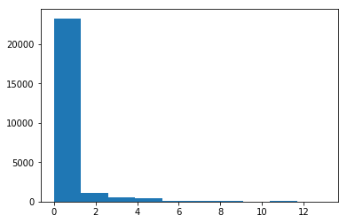

```python
plt.hist(crew_features['dir_n_bad'])
```

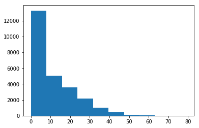

```python
plt.hist(crew_features['count_movies_actor'])
```

```python
crew_features.head()
```

|  | movieId | count_movies_actor | count_movies_actress | count_movies_director | avg_rating_actor | avg_rating_actress | avg_rating_director | dir_n_good | dir_n_bad |
| --- | --- | --- | --- | --- | --- | --- | --- | --- | --- |
| 0 | 1 | 22.0 | 0.0 | 10.0 | 6.560208 | 0.000000 | 7.120000 | 9.0 | 1.0 |
| 1 | 2 | 24.5 | 22.0 | 10.0 | 6.598936 | 6.286905 | 6.450000 | 10.0 | 0.0 |
| 2 | 3 | 45.5 | 27.5 | 11.0 | 6.874081 | 6.386273 | 6.272727 | 11.0 | 0.0 |
| 3 | 4 | 0.0 | 9.5 | 4.0 | 0.000000 | 5.761711 | 5.850000 | 4.0 | 0.0 |
| 4 | 5 | 26.5 | 22.0 | 7.0 | 6.153175 | 6.756250 | 6.014286 | 7.0 | 0.0 |

Merge con el dataset que contiene todos los features anteriores.

```python
rating_movie=rating_movie.merge(crew_features,on='movieId',how='inner')
```

```python
rating_movie.head()
```

|  | userId | movieId | year | month | rating | movie_avg_rating | movie_count_votes | user_avg_rating | user_count_rated | Action | Adventure | Animation | Children | Comedy | Crime | Documentary | Drama | Fantasy | Film-Noir | Horror | IMAX | Musical | Mystery | Romance | Sci-Fi | Thriller | War | Western | tag_1 | … |
| --- | --- | --- | --- | --- | --- | --- | --- | --- | --- | --- | --- | --- | --- | --- | --- | --- | --- | --- | --- | --- | --- | --- | --- | --- | --- | --- | --- | --- | --- | --- |
| 0 | 1 | 2 | 2005 | 4 | 3.5 | 3.21555 | 5537 | 3.697368 | 38 | 0.0 | 3.700000 | 0.0 | 3.625000 | 0.0 | 0.0 | 0.0 | 0.0 | 3.750 | 0.0 | 0.0 | 0.0 | 0.0 | 0.0 | 0.0 | 0.0 | 0.0 | 0.0 | 0.0 | 29.0 | … |
| 1 | 5 | 2 | 1996 | 12 | 3.0 | 3.21555 | 5537 | 4.291667 | 24 | 0.0 | 4.375000 | 0.0 | 4.200000 | 0.0 | 0.0 | 0.0 | 0.0 | 4.000 | 0.0 | 0.0 | 0.0 | 0.0 | 0.0 | 0.0 | 0.0 | 0.0 | 0.0 | 0.0 | 29.0 | … |
| 2 | 88 | 2 | 2004 | 10 | 1.0 | 3.21555 | 5537 | 2.075000 | 40 | 0.0 | 1.916667 | 0.0 | 1.666667 | 0.0 | 0.0 | 0.0 | 0.0 | 1.375 | 0.0 | 0.0 | 0.0 | 0.0 | 0.0 | 0.0 | 0.0 | 0.0 | 0.0 | 0.0 | 29.0 | … |
| 3 | 127 | 2 | 1996 | 11 | 3.0 | 3.21555 | 5537 | 3.952381 | 21 | 0.0 | 3.857143 | 0.0 | 3.500000 | 0.0 | 0.0 | 0.0 | 0.0 | 3.500 | 0.0 | 0.0 | 0.0 | 0.0 | 0.0 | 0.0 | 0.0 | 0.0 | 0.0 | 0.0 | 29.0 | … |
| 4 | 137 | 2 | 2001 | 6 | 3.0 | 3.21555 | 5537 | 3.912088 | 91 | 0.0 | 3.620690 | 0.0 | 3.545455 | 0.0 | 0.0 | 0.0 | 0.0 | 3.700 | 0.0 | 0.0 | 0.0 | 0.0 | 0.0 | 0.0 | 0.0 | 0.0 | 0.0 | 0.0 | 29.0 | … |

#### Calculating predictive value

Se crea la variable a pronosticar.

```python
rating_movie['predict_rating']=rating_movie['rating'].apply(lambda x: _fn_rating_var(x))
```

```python
rating_movie.drop('rating', axis=1, inplace=True)
```

```python
rating_movie.head()
```

|  | userId | movieId | year | month | movie_avg_rating | movie_count_votes | user_avg_rating | user_count_rated | Action | Adventure | Animation | Children | Comedy | Crime | Documentary | Drama | Fantasy | Film-Noir | Horror | IMAX | Musical | Mystery | Romance | Sci-Fi | Thriller | War | Western | tag_1 | tag_2 | … |
| --- | --- | --- | --- | --- | --- | --- | --- | --- | --- | --- | --- | --- | --- | --- | --- | --- | --- | --- | --- | --- | --- | --- | --- | --- | --- | --- | --- | --- | --- | --- |
| 0 | 1 | 2 | 2005 | 4 | 3.21555 | 5537 | 3.697368 | 38 | 0.0 | 3.700000 | 0.0 | 3.625000 | 0.0 | 0.0 | 0.0 | 0.0 | 3.750 | 0.0 | 0.0 | 0.0 | 0.0 | 0.0 | 0.0 | 0.0 | 0.0 | 0.0 | 0.0 | 29.0 | 584.0 | … |
| 1 | 5 | 2 | 1996 | 12 | 3.21555 | 5537 | 4.291667 | 24 | 0.0 | 4.375000 | 0.0 | 4.200000 | 0.0 | 0.0 | 0.0 | 0.0 | 4.000 | 0.0 | 0.0 | 0.0 | 0.0 | 0.0 | 0.0 | 0.0 | 0.0 | 0.0 | 0.0 | 29.0 | 584.0 | … |
| 2 | 88 | 2 | 2004 | 10 | 3.21555 | 5537 | 2.075000 | 40 | 0.0 | 1.916667 | 0.0 | 1.666667 | 0.0 | 0.0 | 0.0 | 0.0 | 1.375 | 0.0 | 0.0 | 0.0 | 0.0 | 0.0 | 0.0 | 0.0 | 0.0 | 0.0 | 0.0 | 29.0 | 584.0 | … |
| 3 | 127 | 2 | 1996 | 11 | 3.21555 | 5537 | 3.952381 | 21 | 0.0 | 3.857143 | 0.0 | 3.500000 | 0.0 | 0.0 | 0.0 | 0.0 | 3.500 | 0.0 | 0.0 | 0.0 | 0.0 | 0.0 | 0.0 | 0.0 | 0.0 | 0.0 | 0.0 | 29.0 | 584.0 | … |
| 4 | 137 | 2 | 2001 | 6 | 3.21555 | 5537 | 3.912088 | 91 | 0.0 | 3.620690 | 0.0 | 3.545455 | 0.0 | 0.0 | 0.0 | 0.0 | 3.700 | 0.0 | 0.0 | 0.0 | 0.0 | 0.0 | 0.0 | 0.0 | 0.0 | 0.0 | 0.0 | 29.0 | 584.0 | … |

### Machine Learning Time.

Se crean los datasets para entrenamiento y test.

```python
rating_movie_train=rating_movie.fillna(0)
```

```python
features = [
    'year',
    'month',
    'movie_avg_rating',
    'movie_count_votes',
    'user_avg_rating',
    'user_count_rated',
    'Action',
    'Adventure',
    'Animation',
    'Children',
    'Comedy',
    'Crime',
    'Documentary',
    'Drama',
    'Fantasy',
    'Film-Noir',
    'Horror',
    'IMAX',
    'Musical',
    'Mystery',
    'Romance',
    'Sci-Fi', 'Thriller', 'War', 'Western', 'tag_1', 'tag_2',
   'tag_3', 'imdb_average_rating', 'imdb_num_votes',
   'count_movies_actor', 'count_movies_actress', 'count_movies_director',
   'avg_rating_actor', 'avg_rating_actress', 'avg_rating_director',
   'dir_n_good', 'dir_n_bad'
]
```

```python
X_train, X_test, y_train, y_test = train_test_split(
    rating_movie_train[features],
    rating_movie_train['predict_rating'],
    test_size=0.30,
    random_state=100
)
```

```python
X_train.shape
```

```
(3312280, 38)
```

#### XGBOOST Model

Se probó una regresión logistica como primer modelo pero tuvo mejor desempeño XGBoost.

```python
xg_reg = xgb.XGBRegressor(
    objective ='binary:logistic',
    colsample_bytree = 0.3,
    learning_rate = 0.1,
    max_depth = 5,
    alpha = 10,
    n_estimators = 4
)
```

```python
#Entrenamiento y predicción
xg_reg.fit(X_train,y_train)
pred_xgboost_probas = xg_reg.predict(X_test)
pred_xgboost = pred_xgboost_probas.round()
```

Esta gráfica podría ayudar para definir un threshold adecuado, pero debido a la naturaleza del problema a resolver no es necesario hacer una optimización para Falsos positivos o Falsos negativos. Por lo que se dejó el threshold en 0.5 para la separación de clases.

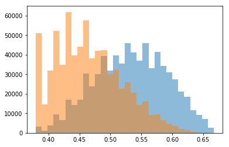

```python
df = pd.DataFrame(y_test)
df['pred_prob'] = pred_xgboost_probas

plt.hist(df[df.predict_rating==1]['pred_prob'], bins=30, alpha=0.5)
plt.hist(df[df.predict_rating==0]['pred_prob'], bins=30, alpha=0.5)
plt.show()
```

Measuring for test.

```python
rmse = np.sqrt(mean_squared_error(y_test, pred_xgboost))
print("RMSE: %f" % (rmse))
```

```
RMSE: 0.527186
```

```python
accuracy = accuracy_score(y_test, pred_xgboost)
print("Accuracy: %.2f%%" % (accuracy * 100.0))
```

```
Accuracy: 72.21%
```

Confusion matrix & classification report.

```python
confusion_matrix(y_test, pred_xgboost)
```

```
array([[523753, 187007],
       [207521, 501268]])
```

```python
print(classification_report(y_test,pred_xgboost))
```

```
              precision    recall  f1-score   support

           0       0.72      0.74      0.73    710760
           1       0.73      0.71      0.72    708789

   micro avg       0.72      0.72      0.72   1419549
   macro avg       0.72      0.72      0.72   1419549
weighted avg       0.72      0.72      0.72   1419549
```

ROC Curve.

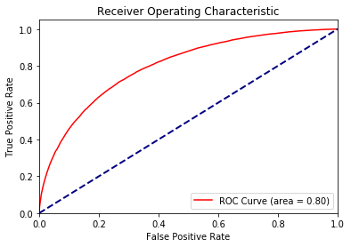

```
Area under ROC: 0.7970612300768828
```

```python
plot_roc(xg_reg,X_test,y_test)
```

En una corrida con menor cantidad de datos de entrenamiento, los shap values arrojaron información valiosa sobre el año de la película, a mayor cantidad de años la variable contribuye de manera negativa, esto debido a que tienden a perder popularidad películas muy viejas.

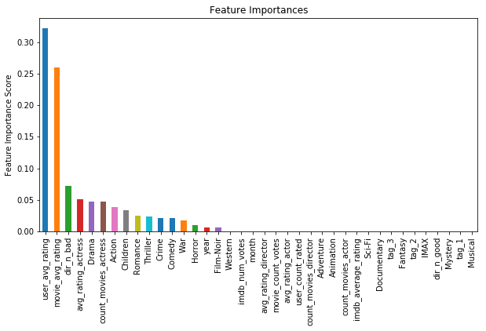

```python
plot_feature_importance(xg_reg, X_test,fig_size=(10,5))
```

```python
import shap

shap.initjs()
explainer=shap.TreeExplainer(xg_reg)
shap_values=explainer.shap_values(X_train)
shap.summary_plot(shap_values,X_train)
```

[output not shown]

#### Segunda corrida modelo XGBoost.

Realicé una segunda corrida de los datos porque descubrí que las variables que más habían aportado al modelo eran aquellas referentes a los promedios de ratings de las películas y estos se calcularon sin tomar en cuenta la fecha. La forma correcta de hacerlo es calculando el valor promedio de las observaciones anteriores a la observación en cuestión. Este cálculo no es tan trivial por lo que se deja para una segunda iteración o revisión.

Se correrá el modelo quitando dichos features.

```python
#rating_movie_train=rating_movie[['userId','movieId','year','month','week','dayofweek','avg_rating','count_votes','predict_rating']]
rating_movie_train=rating_movie.fillna(0)
#del rating_movie
#rating_movie_train=rating_movie[['userId','movieId','rating','avg_rating','count_votes','predict_rating']]
```

```python
features = [
    'year',
    'month',
    #'movie_avg_rating',
    #'movie_count_votes',
    #'user_avg_rating',
    #'user_count_rated',
    'Action',
    'Adventure',
    'Animation',
    'Children',
    'Comedy',
    'Crime',
    'Documentary',
    'Drama',
    'Fantasy',
    'Film-Noir',
    'Horror',
    'IMAX',
    'Musical',
    'Mystery',
    'Romance',
    'Sci-Fi', 'Thriller', 'War', 'Western', 'tag_1', 'tag_2',
   'tag_3', 'imdb_average_rating', 'imdb_num_votes',
   'count_movies_actor', 'count_movies_actress', 'count_movies_director',
   'avg_rating_actor', 'avg_rating_actress', 'avg_rating_director',
   'dir_n_good', 'dir_n_bad'
]
```

```python
X_train, X_test, y_train, y_test = train_test_split(
    rating_movie_train[features],
    rating_movie_train['predict_rating'],
    test_size=0.30,
    random_state=100
)
```

```python
xg_reg = xgb.XGBRegressor(
    objective ='binary:logistic',
    colsample_bytree = 0.3,
    learning_rate = 0.1,
    max_depth = 5,
    alpha = 10,
    n_estimators = 4
)
```

Training & predicting on test set.

```python
xg_reg.fit(X_train,y_train)
pred_xgboost_probas = xg_reg.predict(X_test)
pred_xgboost = pred_xgboost_probas.round()
```

Las clases se solapan más que en el modelo anterior pero no es un clasificador malo debido a que el área de bajo la curva ROC es de .77.

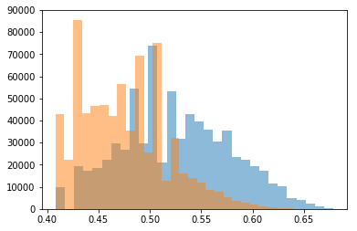

```python
df = pd.DataFrame(y_test)
df['pred_prob'] = pred_xgboost_probas

plt.hist(df[df.predict_rating==1]['pred_prob'], bins=30, alpha=0.5)
plt.hist(df[df.predict_rating==0]['pred_prob'], bins=30, alpha=0.5)
plt.show()
```

Measuring for test.

```python
rmse = np.sqrt(mean_squared_error(y_test, pred_xgboost))
print("RMSE: %f" % (rmse))
```

```
RMSE: 0.548520
```

```python
accuracy = accuracy_score(y_test, pred_xgboost)
print("Accuracy: %.2f%%" % (accuracy * 100.0))
```

```
Accuracy: 69.91%
```

Confusion matrix & classification report.

```python
confusion_matrix(y_test, pred_xgboost)
```

```
array([[513049, 197711],
       [229394, 479395]])
```

```python
print(classification_report(y_test,pred_xgboost))
```

```
              precision    recall  f1-score   support

           0       0.69      0.72      0.71    710760
           1       0.71      0.68      0.69    708789

   micro avg       0.70      0.70      0.70   1419549
   macro avg       0.70      0.70      0.70   1419549
weighted avg       0.70      0.70      0.70   1419549
```

ROC Curve.

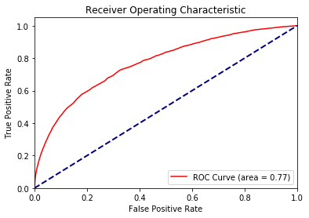

```
Area under ROC: 0.7694604306617817
```

```python
plot_roc(xg_reg,X_test,y_test)
```

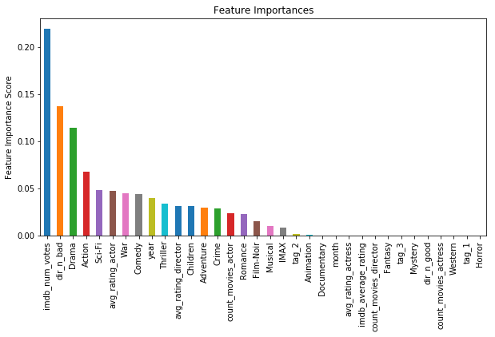

```python
plot_feature_importance(xg_reg, X_test,fig_size=(10,5))
```

### Siguientes pasos

Cálculo correcto de promedios de usuarios y películas. Tomando en cuenta sólo aquellos datos antes de la observación en cuestión.

Normalización y/o logaritmo de las variables para reducir variabilidad.

Incluir información del idioma de la película y presupuesto gastado, no es una regla pero se piensa que aquellas películas con un budget grande tienden a tener buenos ratings.

### Intentos fallidos

Cluster de géneros de películas. Se intentó hacer una clusterización basada en los genéros pero la métrica silhouette no fue satisfactoria por lo que se sigió con otro camino.

### Conclusiones

Fue primordial haber incluido información acerca del staff de la película. Sin estos features el clasificador no tenía un buen desempeño.

Se invirtió una mayor cantidad de tiempo en hacer feature engineering pues es lo más importante ante un problema predicción ya que se debe alimentar el modelo con datos muy significativos y explicativos que ayuden a que el algoritmo usado pueda detectar patrones de mejor forma.

En un inicio se probó con una regresión logística pero no se obtuvo un buen desempeño, se decidió probar con un modelo más robusto (Gradient Boosting) pues no es un problema básico.